# Day 6

## Review

**Population Mean**

$$\mu = {1 \over N}\sum\limits_{i=1}^Nx_i$$

$$\mu = {\sum\limits_{i=1}^Nx_i\over N}$$

**Sample Mean**

$$\bar{x} = {1 \over n}\sum\limits_{i=1}^nx_i$$

$$\bar{x} = {\sum\limits_{i=1}^nx_i\over n}$$

#### Spread of data

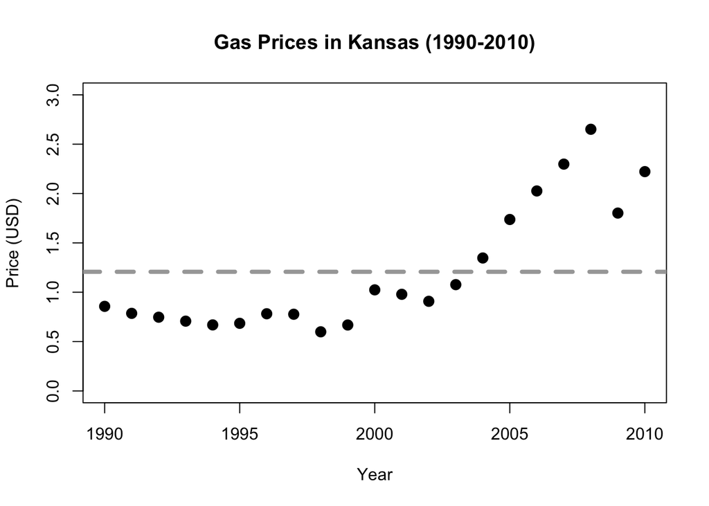

##### **Range**

$$\text{Range} = \text{Maximum} - \text{Minimum}$$

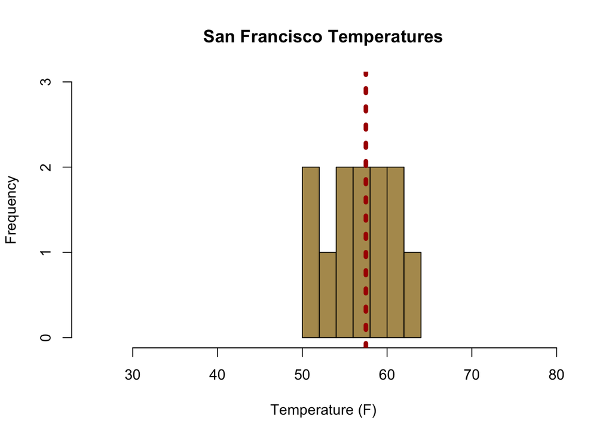

Smaller spread is usually **closer to the mean**

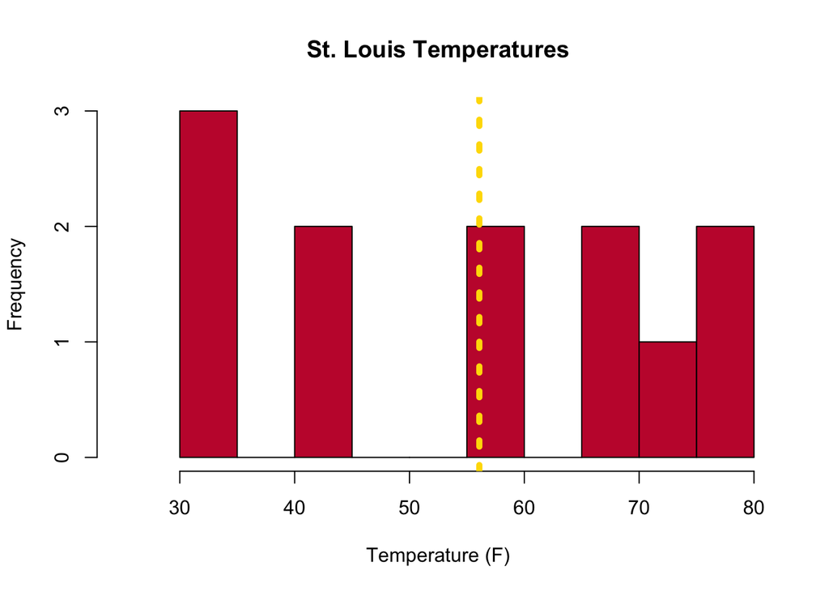

Larger spread is usually **further from the mean**

##### **Variance**

**Population variance** (denoted $\sigma^2$):

$$\sigma^2 = {{{\sum\limits_{i=1}^N}(x_i-\mu)^2}\over N}$$

**Sample variance** (denoted $s^2$):

$$s^2 = {{{\sum\limits_{i=1}^n}(x_i-\bar{x})^2}\over (n-1)}$$

##### **Standard Deviation**

$$\sqrt{\sigma^2}=\sigma \rightarrow \text{Population Standard Deviation}$$

$$\sqrt{s^2}=s \rightarrow \text{Sample Standard Deviation}$$

- What is the variance and standard deviation of the data below?

$$\begin{array}{|c|c|c|c|c|c|c|c|c|}
\hline
\text{Year} & 2004 & 2005 & 2006 & 2007 &2008 & 2009 & 2010 \\
\hline
\text{Price} & 1.347 & 1.737 & 2.026 & 2.298 & 2.651 & 1.802 & 2.222 \\
\hline
\end{array}$$

$$\bar{x}=2.012$$

##### **The Empirical Rule**

For a population that has an *approximately* **bell-shaped** distribution:

- $\approx 68\%$ of the data is within **ONE** standard deviation of the mean

$$\approx 68\% = \begin{cases}
\mu - \sigma \\
\mu + \sigma
\end{cases}$$

- $\approx 95\%$$ of the data is within **TWO** standard deviations of the mean

$$\approx 95\% = \begin{cases}
\mu - 2\sigma \\
\mu + 2\sigma
\end{cases}$$

- $\approx$ **All** or *almost all* of the data is within **THREE** standard deviations of the mean

$$\approx 100\% = \begin{cases}
\mu - 3\sigma \\
\mu + 3\sigma
\end{cases}$$

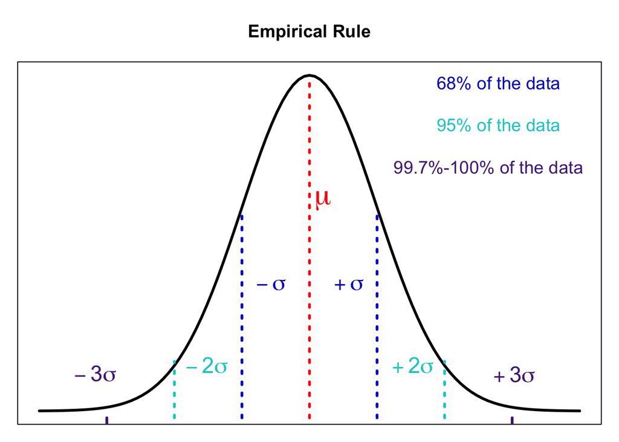

**Questions?**

**Goals for Today:**

1. Introduce the common measures of position
2. Develop the five number summary
3. Discuss the concept of outliers

## Measures of Position

Suppose we have a male white-tailed deer who’s $141$ lbs and a female who’s $112$ lbs

- We have the tools to say how different they are from each other
- But how can we say who’s more different from their specific group?

We need to define a way to look at differences *relative* to groups

- This is referred to as **position**
  - We’ll develop three general measures of it:
    - **z-scores**
    - **percentiles**
    - **quartiles**

### z-scores

Let $x$ be a value from a **population** with mean $\mu$

- The z-score is:

$$z={x-\mu \over \sigma}$$

- For a sample:

$$z={x-\bar{x} \over s}$$

> Suppose you score $x=75$ on Exam 1. The class average on Exam 1 is $80$ with a standard deviation of 5. The $z$-score of your exam is:

$$z={75-80 \over 5}=-1$$

**Population:**

$$z={x-\mu \over \sigma}$$

**Sample:**

$$z={x-\bar{x} \over s}$$

A $z$-score data value $x$ is the **number of standard deviations** $x$ is from the **mean** of the data set

- $z < 0 \Rightarrow$ the value of $x$ is **less than the mean**
- $z = 0 \Rightarrow$ the value of $x$ is **equal to the mean**
- $z > 0 \Rightarrow$ the value of $x$ is **greater than the mean**

**In our example:**

$$x=75$$

$$z=-1$$

- Note: this measure is *unitless*

The **mean** weight for adult **male** white-tailed deer is $\mu=150$ lbs, with a *standard deviation* of $\sigma = 12$ lbs

The **mean** weight for adult **female** white-tailed deer is $\mu=105$ lbs, with a *standard deviation* of $\sigma = 9$ lbs

Who is heavier relative to their sex, a male deer at $141$ lbs or a female deer at $112$ lbs?

$$z={x-\mu \over \sigma}$$

### z-scores and the Empirical Rule

**Recall the Empirical Rule:**

**With z-scores:**

- $\approx 68\%$ of the data will be between $z=-1$ and $z=1$
- $\approx 95\%$ of the data will be between $z=-2$ and $z=2$
- $\approx 100\%$ of the data will be between $z=-3$ and $z=3$

**Both of these imply a bell-shaped distribution**

A data set has a **mean** of $20$ and a **standard deviation** of $3$. A histogram for the data is shown below.

Is it appropriate to use the Empirical Rule to approximate the proportion of the data between $14$ and $26$? If so, find the approximation. If not, explain why not.

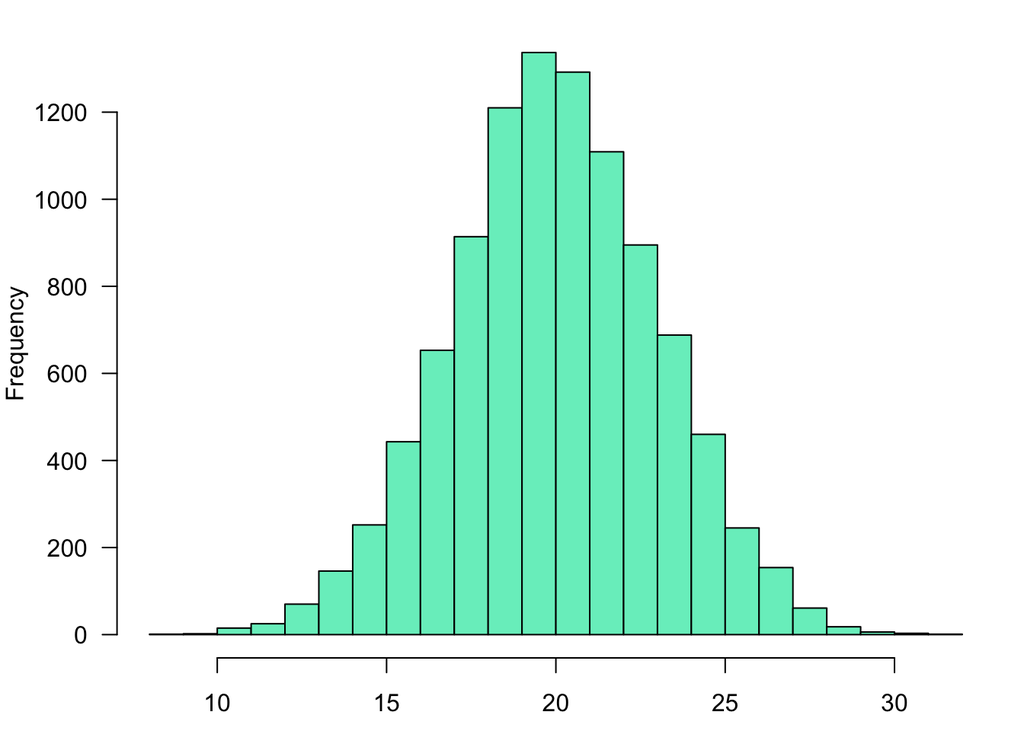

### Quartiles

**Every data set has three quartiles:**

$1^{st}$ quartile, denoted $\textbf{Q}_1$ separates the **lowest** $25\%$ of the data from the **highest** $75\%$

$2^{nd}$ quartile, denoted $\textbf{Q}_2$ separates the **lowest** $50\%$ of the data from the **highest** $50\%$ ($Q_2 = Median$)

$3^{rd}$ quartile, denoted $\textbf{Q}_3$ separates the **lowest** $75\%$ of the data from the **highest** $25\%$

The quartiles of the below data set of size $n=8$:

$$\begin{array}{|c|c|c|c|c|c|c|}
\hline
1 & 2 & 2 & 3 & 4 & 5 & 7 & 12 \\
\hline
\end{array}$$

$$\text{Q}_1 = 2$$

$$\text{Q}_2 = 3.5\ \text{(Median)}$$

$$\text{Q}_3 = 6$$

### Percentiles

For a number $p$ between $1$ and $99$, the $p^{th}$ **percentile** separates the lowest $p\%$ of the data from the highest $(100-p)\%$

- Quartiles separate data into $4$ parts
- Each part is $\approx 25\%$ of the data
- Percentiles divide the data set into $100$ parts

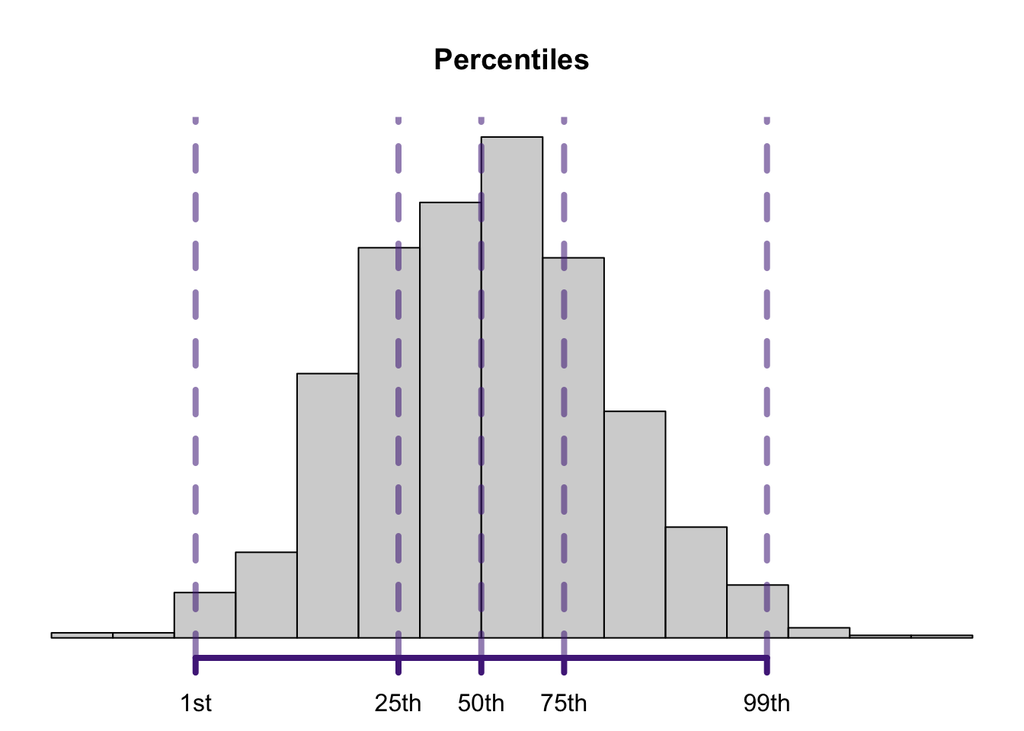

**Procedure for Computing Percentiles or Quartiles**

1. Arrange the data in increasing order
2. Let $n$ be the number of values in the data set. For the $p^{th}$ percentile, compute the value:

$$L={p\over 100}*n$$

3. If $L$ is a whole number, the $p^{th}$ percentile is the average of the number in position $L$ and the number in position $L+1$
- If $L$ is **not** a whole number, round it up the the next higher whole number. The $p^{th}$ percentile is the number in the position corresponding to the rounded-up value

What’s the **position** for $85^{th}$ **percentile** for **male deer** in a data set of $n=96$?

$$L={p\over 100}*n$$

$$p = 85$$

$$n = 96$$

$$L={85\over 100}*96=81.6 \rightarrow 82$$

### Five-Number Summary

The **five-number summary** is a set of five measures of position computed from a data set. The summary consists of:

$$\begin{array}{|c|c|c|c|c|c|c|}
\hline
\text{Min} & \text{Q}_1 & \text{Median} & \text{Q}_3 & \text{Max} \\
\hline
\end{array}$$

**Below is a table of exam scores from the STAT 225 second Exam**

$$\begin{array}{|c|c|c|c|c|c|c|}
\hline
83 & 72 & 67 & 55 & 53 & 79 & 91 & 60 & 81 & 84 \\
\hline
\end{array}$$

The five number summary is:

$$\begin{array}{|c|c|c|c|c|c|c|}
\hline
\text{Min} & \text{Q}_1 & \text{Median} & \text{Q}_3 & \text{Max} \\
\hline
53 & 60 & 75.5 & 83 & 91\\
\hline
\end{array}$$

**How does a new value of 86 compare to the exam scores?**

**What about 74?**

$Q_1 < 74 < Median \Rightarrow 74$ is greater than $25\%$ of the exam scores, but less than half of the exams

### Outliers

An **outlier** is a value that is considerably large or smaller than most of the values in a data set

What do you do with outliers?

- If it’s a mistake/type/bad measure, ideally fix it
- If you can’t fix it, chuck it
- If it’s a valid observation, you keep it in the data
  - **You keep outliers if they’re valid observations**
    - **Keep outliers if they’re valid**
    - Resistant statistics

**How do you find outliers?**

### Interquartile Range (IQR)

The **IQR** is a measure of spread that is often used to detect outliers

- Take the difference between $Q_1$ and $Q_3$:

$$\text{IQR} = \text{Q}_3 - \text{Q}_1$$

**Notice the IQR contains the middle $50\%$ of the data**

- To find outliers with the IQR we use the **IQR Method**
1. Define **outlier boundaries:**

$$\text{Lower Outlier Boundary} = \text{Q}_1 - 1.5*\text{IQR}$$

$$\text{Upper Outlier Boundary} = \text{Q}_3 + 1.5*\text{IQR}$$

2. Check to see if any data is outside of these boundaries:

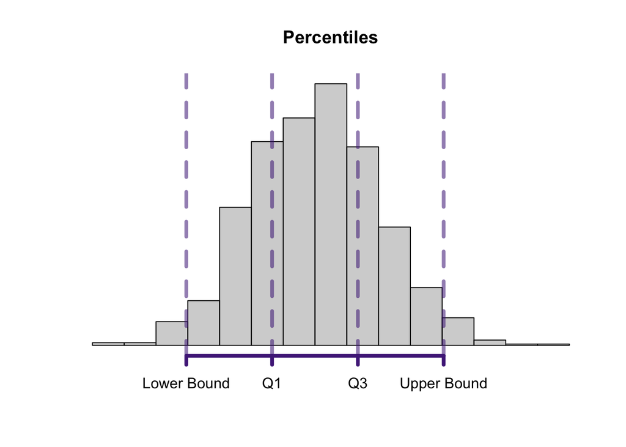

**Recall our five-number summary of the exam data:**

$$\begin{array}{|c|c|c|c|c|c|c|}
\hline
\text{Min} & \text{Q}_1 & \text{Median} & \text{Q}_3 & \text{Max} \\
\hline
53 & 60 & 75.5 & 83 & 91\\
\hline
\end{array}$$

**The IQR for the dataset is:**

$$\text{IQR} = \text{Q}_3 - \text{Q}_1 = 83 - 60 = 23$$

- Defining the **outlier boundaries**:

$$\text{Q}_1 - 1.5*\text{IQR} = 60-(1.5*23)=25.5$$